# Lab 3 CS7325

## Contributors: Taylor King and Morgan Mote

##### [4 points] Select and describe a pre-trained model. You should clearly explain the pre-trained model you selected, describing its architecture, inputs / outputs, and the type of learning it performs as well as comparing learning to halloween candy (e.g., detection, segmentation, generative modeling--whatever it was originally designed to perform). Your explanation should demonstrate that you understand how the model works, not just how to run it.

```
If adapting to a new dataset: Explain why this model is appropriate for your chosen task.
If changing an element in the model: Explain a potential limitation of the current model and motivate your modifications.
In either case, create a visual overview of the pre-trained model to help in your text description.
```

As the starting point for this lab, we use a U-Net semantic segmentation model with a ResNet-34 encoder pretrained on ImageNet. U-Net has an encoder-decoder architecture: the encoder repeatedly applies convolution and downsampling to learn increasingly abstract image features, while the decoder upsamples those features back to the original image resolution. Skip connections copy feature maps from matching encoder stages into the decoder, which helps the model combine high-level context with fine spatial detail. This is especially important for segmentation because the model must understand what the object is and where its boundary is.

The pretrained portion is the ResNet-34 encoder. Because it was trained for ImageNet classification, it has already learned reusable visual primitives such as edges, corners, textures, color transitions, and object parts. The original ImageNet learning task is classification: given an image, predict one image-level label. Our task is semantic segmentation: given an RGB image tensor with shape 3 x H x W, predict a class score map with shape C x H x W. In this lab C = 2, representing foreground object and background, so every pixel receives its own class prediction. A Halloween candy analogy is that classification asks whether the bowl contains M&M's, while segmentation outlines exactly which pixels belong to the M&M bag and which pixels belong to the table, wrapper shadows, or background.

This model is appropriate for the chosen task because the Oxford-IIIT Pet dataset provides pixel-level masks, and U-Net is designed for dense pixel prediction rather than only image-level labels. It gives us a strong pretrained visual backbone without requiring us to train all low-level features from scratch. A limitation is that ImageNet pretraining does not specifically teach robustness to poor lighting, glare, or low contrast. To address that limitation, we adapt the training pipeline with low-light and contrast augmentation and then fine-tune the model for foreground/background segmentation.

### A visual overview of the pre-trained model:

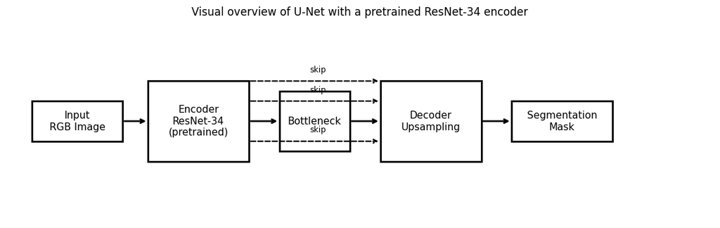

```python
import matplotlib.pyplot as plt
from matplotlib.patches import Rectangle

fig, ax = plt.subplots(figsize=(14, 4))
ax.set_xlim(0, 14)
ax.set_ylim(0, 4)
ax.axis("off")

blocks = [
    (0.5, 1.6, 1.8, 0.8, "Input\nRGB Image"),
    (2.8, 1.2, 2.0, 1.6, "Encoder\nResNet-34\n(pretrained)"),
    (5.4, 1.4, 1.4, 1.2, "Bottleneck"),
    (7.4, 1.2, 2.0, 1.6, "Decoder\nUpsampling"),
    (10.0, 1.6, 2.0, 0.8, "Segmentation\nMask"),
]
for x, y, w, h, label in blocks:
    ax.add_patch(Rectangle((x, y), w, h, fill=False, linewidth=2))
    ax.text(x + w/2, y + h/2, label, ha="center", va="center", fontsize=11)

ax.annotate("", xy=(2.8, 2.0), xytext=(2.3, 2.0), arrowprops=dict(arrowstyle="->", lw=2))
ax.annotate("", xy=(5.4, 2.0), xytext=(4.8, 2.0), arrowprops=dict(arrowstyle="->", lw=2))
ax.annotate("", xy=(7.4, 2.0), xytext=(6.8, 2.0), arrowprops=dict(arrowstyle="->", lw=2))
ax.annotate("", xy=(10.0, 2.0), xytext=(9.4, 2.0), arrowprops=dict(arrowstyle="->", lw=2))

for y1, y2, txt in [(2.8, 2.8, "skip"), (2.4, 2.4, "skip"), (1.6, 1.6, "skip")]:
    ax.annotate("", xy=(7.4, y2), xytext=(4.8, y1), arrowprops=dict(arrowstyle="->", lw=1.5, linestyle="--"))
    ax.text(6.0, y1 + 0.18, txt, fontsize=9)

plt.title("Visual overview of U-Net with a pretrained ResNet-34 encoder")
plt.show()
```

##### [3 points] Business/Policy case. Clearly describe the task you are solving, including any auxiliary task used to enhance performance. You should justify why the new task(s) or modification(s) are needed and how they could be used in a business case or policy case. Acknowledge that business cases should be governed by the will of the governed. Describe a realistic business or policy use case that motivates your problem.

# Define use case

The task this lab solves is semantic segmentation under degraded lighting conditions. The model predicts a foreground mask for each image, meaning it must identify which pixels belong to the object and which pixels belong to the background. The technical motivation comes from safety-critical vision settings where objects must still be separated from the background when brightness, contrast, and visibility are poor.

The motivating use case is autonomous driving or roadway monitoring, where traditional computer vision systems often struggle with small or distant objects, overlapping objects, and harsh lighting. Distance can sometimes be addressed with sensors such as LiDAR, but lighting remains a major camera-specific problem. Dusk, dawn, bright oncoming headlights, shadows from overpasses, and glare from signs or wet pavement can all make object boundaries harder to detect. The auxiliary task used to improve performance is robustness-oriented augmentation: the training images are modified with reduced brightness, contrast variation, and mild blur to simulate low-light conditions.

A realistic business and policy motivation comes from public-facing perception systems: driver assistance, robotic inspection, traffic monitoring, or municipal safety analytics. If a segmentation model fails in difficult lighting, it can miss boundaries, over-segment irrelevant regions, or produce unstable predictions. That creates technical risk, legal risk, and public trust risk. Due to dataset accessibility constraints with BDD100K segmentation masks, this experiment uses the Oxford-IIIT Pet dataset, which provides pixel-level annotations. The pet masks are not an autonomous-driving benchmark, but they let us test the core transfer-learning mechanism: whether a pretrained segmentation model can be fine-tuned and stress-tested under simulated low-light conditions.

The adaptation is therefore motivated by governance as much as accuracy: a model that works only under ideal imaging conditions is not sufficient for deployment in environments that affect public safety. In a business setting, improved robustness can reduce false alarms, missed detections, manual review, and system distrust. In a policy setting, any deployment should be governed by the will of the governed: communities affected by the technology should have a say in where it is used, what failure rates are acceptable, and what human oversight or appeal processes are required. The business case is stronger when the technical design explicitly accounts for realistic operating conditions and transparent limitations.

##### [3 points] Load and Adapt your model. First, load the pre-trained model and run it on some example images (either for classification or generation). Show outputs and explain the outputs of the model. Second, adapt the model as motivated by your desired task (either through training on a new dataset or through changing an element to the model). Be sure the adapted model converges by showing plots of the loss/evaluation criteria over batches/epochs.

```python
import subprocess
import sys

subprocess.check_call([sys.executable, "-m", "pip", "install", "segmentation-models-pytorch"])
print(f"Using Python: {sys.executable}")
```

```
Using Python: d:\Documents\Grad_School\SMU\CS7325_Deep_Learning\CS7325-Labs\.venv\Scripts\python.exe
```

```python
import subprocess
import sys

import torch

compat = {
    "2.11": "0.26",
    "2.10": "0.25",
    "2.9": "0.24",
    "2.8": "0.23",
    "2.7": "0.22",
    "2.6": "0.21",
    "2.5": "0.20",
    "2.4": "0.19",
    "2.3": "0.18",
    "2.2": "0.17",
    "2.1": "0.16",
}

def install_matching_torchvision():
    torch_mm = ".".join(torch.__version__.split("+")[0].split(".")[:2])
    torchvision_mm = compat.get(torch_mm)
    if torchvision_mm is None:
        raise RuntimeError(f"No torchvision compatibility rule configured for torch {torch.__version__}.")
    subprocess.check_call([
        sys.executable,
        "-m",
        "pip",
        "install",
        "--upgrade",
        "--force-reinstall",
        f"torchvision=={torchvision_mm}.*",
    ])

try:
    import torchvision
    import torchvision.transforms as T
except RuntimeError as exc:
    if "torchvision::nms does not exist" not in str(exc):
        raise
    print("Detected a torch/torchvision mismatch in the active Jupyter kernel.")
    print(f"Python: {sys.executable}")
    print(f"torch: {torch.__version__}")
    install_matching_torchvision()
    raise RuntimeError(
        "Installed a matching torchvision build for this kernel. Restart the kernel, then run the notebook from this cell again."
    ) from exc

print("torch:", torch.__version__)
print("torchvision:", torchvision.__version__)
print("Python:", sys.executable)
```

```
torch: 2.6.0+cu124
torchvision: 0.21.0+cu124
Python: d:\Documents\Grad_School\SMU\CS7325_Deep_Learning\CS7325-Labs\.venv\Scripts\python.exe
```

```python
import random
import numpy as np
import matplotlib.pyplot as plt
from pathlib import Path
from PIL import Image, ImageEnhance, ImageFilter

import torch
import torch.nn as nn
import torch.optim as optim
from torch.utils.data import Dataset, DataLoader, Subset
import torchvision.transforms as T
from torchvision.datasets import OxfordIIITPet

import segmentation_models_pytorch as smp

SEED = 42
IMG_SIZE = 256
BATCH_SIZE = 8
NUM_WORKERS = 0
EPOCHS = 4
LR = 1e-3
WEIGHT_DECAY = 1e-4
MAX_TRAIN_SAMPLES = 800
MAX_VAL_SAMPLES = 200

device = "cuda" if torch.cuda.is_available() else "cpu"
print("Using device:", device)

def set_seed(seed=42):
    random.seed(seed)
    np.random.seed(seed)
    torch.manual_seed(seed)
    if torch.cuda.is_available():
        torch.cuda.manual_seed_all(seed)

set_seed(SEED)
```

```
Using device: cuda
```

```python
class LowLightPetSegmentation(Dataset):
    def __init__(self, root, split="trainval", img_size=256, low_light=False):
        self.ds = OxfordIIITPet(root=root, split=split, target_types="segmentation", download=True)
        self.img_size = img_size
        self.low_light = low_light
        self.img_resize = T.Resize((img_size, img_size), interpolation=T.InterpolationMode.BILINEAR)
        self.mask_resize = T.Resize((img_size, img_size), interpolation=T.InterpolationMode.NEAREST)
        self.to_tensor = T.ToTensor()

    def _apply_low_light(self, image):
        brightness_factor = random.uniform(0.35, 0.75)
        contrast_factor = random.uniform(0.75, 1.25)
        image = ImageEnhance.Brightness(image).enhance(brightness_factor)
        image = ImageEnhance.Contrast(image).enhance(contrast_factor)
        if random.random() < 0.4:
            image = image.filter(ImageFilter.GaussianBlur(radius=random.uniform(0.2, 1.0)))
        return image

    def __len__(self):
        return len(self.ds)

    def __getitem__(self, idx):
        image, mask = self.ds[idx]
        image = image.convert("RGB")
        mask = mask.copy()

        if self.low_light:
            image = self._apply_low_light(image)

        image = self.img_resize(image)
        mask = self.mask_resize(mask)

        image = self.to_tensor(image)

        # Oxford-IIIT Pet trimap labels: 1=pet, 2=background, 3=border
        # Convert to binary segmentation: pet -> 1, everything else -> 0
        mask_np = np.array(mask, dtype=np.int64)
        binary_mask = (mask_np == 1).astype(np.int64)
        mask = torch.from_numpy(binary_mask)

        return image, mask
```

```python
root = "./data"

base_train_full = LowLightPetSegmentation(root=root, split="trainval", img_size=IMG_SIZE, low_light=False)
adapted_train_full = LowLightPetSegmentation(root=root, split="trainval", img_size=IMG_SIZE, low_light=True)
val_full = LowLightPetSegmentation(root=root, split="test", img_size=IMG_SIZE, low_light=False)

train_indices = list(range(min(MAX_TRAIN_SAMPLES, len(base_train_full))))
val_indices = list(range(min(MAX_VAL_SAMPLES, len(val_full))))

base_train_ds = Subset(base_train_full, train_indices)
adapted_train_ds = Subset(adapted_train_full, train_indices)
val_ds = Subset(val_full, val_indices)

base_train_loader = DataLoader(base_train_ds, batch_size=BATCH_SIZE, shuffle=True, num_workers=NUM_WORKERS, pin_memory=True)
adapted_train_loader = DataLoader(adapted_train_ds, batch_size=BATCH_SIZE, shuffle=True, num_workers=NUM_WORKERS, pin_memory=True)
val_loader = DataLoader(val_ds, batch_size=BATCH_SIZE, shuffle=False, num_workers=NUM_WORKERS, pin_memory=True)

print("Base train samples:", len(base_train_ds))
print("Adapted train samples:", len(adapted_train_ds))
print("Validation samples:", len(val_ds))
```

```
Base train samples: 800
Adapted train samples: 800
Validation samples: 200
```

```python
NUM_CLASSES = 2

def build_model():
    return smp.Unet(
        encoder_name="resnet34",
        encoder_weights="imagenet",
        in_channels=3,
        classes=NUM_CLASSES
    ).to(device)

model = build_model()
print(model.__class__.__name__)
```

```
Unet
```

```python
pretrained_model = build_model()
pretrained_model.eval()
```

[output not shown]

[output cut: 187 more lines]

[output not shown]

```python
# Load a single validation example directly for a quick preview/debug step.
# This avoids starting DataLoader worker processes just to fetch one image.
image, mask = val_ds[0]
images = image.unsqueeze(0).to(device, non_blocking=True)
masks = mask.unsqueeze(0)
print("Loaded one validation image:", tuple(images.shape), "on", images.device)
```

```
Loaded one validation image: (1, 3, 256, 256) on cuda:0
```

```python
with torch.no_grad():
    logits = pretrained_model(images)
    probs = torch.softmax(logits, dim=1)[:, 1].cpu().numpy()
    preds = torch.argmax(logits, dim=1).cpu().numpy()
```

```python
images_np = images.cpu().permute(0, 2, 3, 1).numpy()
masks_np = masks.numpy()
```

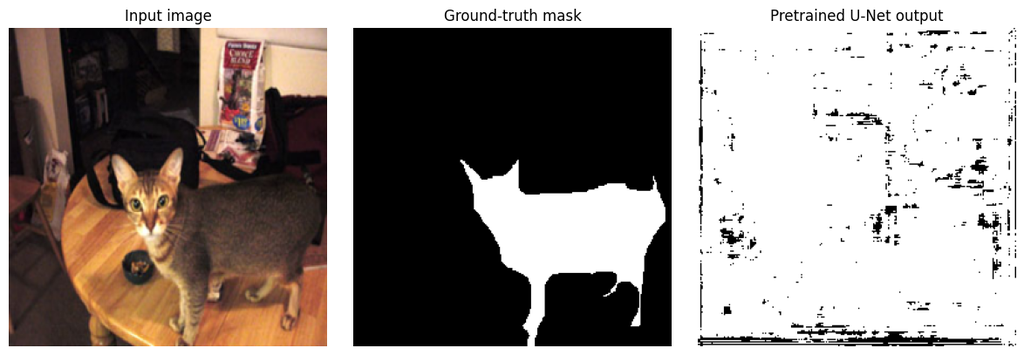

```python
n_show = min(3, len(images_np))
plt.figure(figsize=(12, 4 * n_show))
for i in range(n_show):
    plt.subplot(n_show, 3, 3*i + 1)
    plt.imshow(images_np[i])
    plt.title("Input image")
    plt.axis("off")

    plt.subplot(n_show, 3, 3*i + 2)
    plt.imshow(masks_np[i], cmap="gray")
    plt.title("Ground-truth mask")
    plt.axis("off")

    plt.subplot(n_show, 3, 3*i + 3)
    plt.imshow(preds[i], cmap="gray")
    plt.title("Pretrained U-Net output")
    plt.axis("off")

plt.tight_layout()
plt.show()
```

The pretrained U-Net produces a mask-shaped output immediately because the decoder architecture maps feature activations back to pixel space. However, before task-specific fine-tuning, those predictions are not yet aligned with the Oxford-IIIT Pet foreground/background masks. The ImageNet-pretrained encoder contributes general visual features, but ImageNet supervision is image-level classification, not pixel-level segmentation. The decoder and segmentation head therefore still need to learn the boundary structure of this target dataset.

The adaptation step trains two versions of the same architecture. The baseline model is fine-tuned on standard pet images, while the adapted model is fine-tuned on images modified with low-light augmentation. Both models use the same ResNet-34 U-Net architecture, optimizer, number of epochs, sample limits, and validation set. This keeps the comparison focused on the adaptation strategy rather than on architecture changes.

```python
import time

try:
    from tqdm.auto import tqdm
except ImportError:
    tqdm = None

def make_progress_bar(loader, desc):
    if tqdm is None:
        return loader
    return tqdm(loader, desc=desc, leave=False, dynamic_ncols=True)

def freeze_encoder(model):
    for p in model.encoder.parameters():
        p.requires_grad = False

def unfreeze_encoder(model):
    for p in model.encoder.parameters():
        p.requires_grad = True

IGNORE_INDEX = -1
criterion = nn.CrossEntropyLoss()

@torch.no_grad()
def compute_batch_iou(logits, targets, num_classes=2):
    preds = torch.argmax(logits, dim=1)
    ious = []
    for cls in range(num_classes):
        pred_c = (preds == cls)
        target_c = (targets == cls)
        intersection = (pred_c & target_c).sum().item()
        union = (pred_c | target_c).sum().item()
        if union > 0:
            ious.append(intersection / union)
    return float(np.mean(ious)) if len(ious) else 0.0

@torch.no_grad()
def pixel_accuracy(logits, targets):
    preds = torch.argmax(logits, dim=1)
    return (preds == targets).float().mean().item()

def train_one_epoch(model, loader, optimizer, criterion, scaler, device, desc="Training"):
    model.train()
    running_loss = 0.0
    running_acc = 0.0
    running_iou = 0.0

    progress = make_progress_bar(loader, desc)

    for batch_idx, (images, masks) in enumerate(progress, start=1):
        images = images.to(device, non_blocking=True)
        masks = masks.to(device, non_blocking=True)

        optimizer.zero_grad(set_to_none=True)

        with torch.cuda.amp.autocast(enabled=(device == "cuda")):
            logits = model(images)
            loss = criterion(logits, masks)

        scaler.scale(loss).backward()
        scaler.step(optimizer)
        scaler.update()

        running_loss += loss.item()
        running_acc += pixel_accuracy(logits.detach(), masks)
        running_iou += compute_batch_iou(logits.detach(), masks, num_classes=NUM_CLASSES)

        if tqdm is not None:
            progress.set_postfix({
                "loss": f"{running_loss / batch_idx:.4f}",
                "acc": f"{running_acc / batch_idx:.4f}",
                "iou": f"{running_iou / batch_idx:.4f}",
            })

    n = len(loader)
    return running_loss / n, running_acc / n, running_iou / n

@torch.no_grad()
def validate_one_epoch(model, loader, criterion, device, desc="Validating"):
    model.eval()
    running_loss = 0.0
    running_acc = 0.0
    running_iou = 0.0

    progress = make_progress_bar(loader, desc)

    for batch_idx, (images, masks) in enumerate(progress, start=1):
        images = images.to(device, non_blocking=True)
        masks = masks.to(device, non_blocking=True)

        with torch.cuda.amp.autocast(enabled=(device == "cuda")):
            logits = model(images)
            loss = criterion(logits, masks)

        running_loss += loss.item()
        running_acc += pixel_accuracy(logits, masks)
        running_iou += compute_batch_iou(logits, masks, num_classes=NUM_CLASSES)

        if tqdm is not None:
            progress.set_postfix({
                "loss": f"{running_loss / batch_idx:.4f}",
                "acc": f"{running_acc / batch_idx:.4f}",
                "iou": f"{running_iou / batch_idx:.4f}",
            })

    n = len(loader)
    return running_loss / n, running_acc / n, running_iou / n

@torch.no_grad()
def collect_batch_ious(model, loader, device):
    model.eval()
    batch_ious = []
    for images, masks in loader:
        images = images.to(device, non_blocking=True)
        masks = masks.to(device, non_blocking=True)
        logits = model(images)
        batch_ious.append(compute_batch_iou(logits, masks, num_classes=NUM_CLASSES))
    return batch_ious
```

```python
def run_experiment(train_loader, experiment_name, use_adaptation=False):
    model = build_model()
    freeze_encoder(model)

    optimizer = optim.AdamW(
        filter(lambda p: p.requires_grad, model.parameters()),
        lr=LR,
        weight_decay=WEIGHT_DECAY
    )
    scaler = torch.cuda.amp.GradScaler(enabled=(device == "cuda"))

    history = {
        "train_loss": [], "val_loss": [],
        "train_acc": [], "val_acc": [],
        "train_iou": [], "val_iou": []
    }

    best_val_iou = -1.0
    best_path = f"{experiment_name.replace(' ', '_').lower()}_best.pth"

    experiment_start = time.time()

    for epoch in range(EPOCHS):
        epoch_start = time.time()
        print(f"\n{experiment_name} | Epoch {epoch+1}/{EPOCHS}")
        if epoch == 1:
            unfreeze_encoder(model)
            optimizer = optim.AdamW(model.parameters(), lr=LR * 0.3, weight_decay=WEIGHT_DECAY)

        train_loss, train_acc, train_iou = train_one_epoch(
            model, train_loader, optimizer, criterion, scaler, device,
            desc=f"{experiment_name} train {epoch+1}/{EPOCHS}"
        )
        val_loss, val_acc, val_iou = validate_one_epoch(
            model, val_loader, criterion, device,
            desc=f"{experiment_name} val {epoch+1}/{EPOCHS}"
        )

        history["train_loss"].append(train_loss)
        history["val_loss"].append(val_loss)
        history["train_acc"].append(train_acc)
        history["val_acc"].append(val_acc)
        history["train_iou"].append(train_iou)
        history["val_iou"].append(val_iou)

        epoch_seconds = time.time() - epoch_start
        print(
            f"{experiment_name} | Epoch {epoch+1}/{EPOCHS} | "
            f"train_loss={train_loss:.4f} val_loss={val_loss:.4f} | "
            f"train_acc={train_acc:.4f} val_acc={val_acc:.4f} | "
            f"train_iou={train_iou:.4f} val_iou={val_iou:.4f} | "
            f"time={epoch_seconds/60:.1f} min"
        )

        if val_iou > best_val_iou:
            best_val_iou = val_iou
            torch.save(model.state_dict(), best_path)
            print(f"Saved new best model: val_iou={best_val_iou:.4f} -> {best_path}")

    total_minutes = (time.time() - experiment_start) / 60
    print(f"\n{experiment_name} complete in {total_minutes:.1f} min | best_val_iou={best_val_iou:.4f}")

    model.load_state_dict(torch.load(best_path, map_location=device))
    return model, history, best_path
```

```python
baseline_model, baseline_history, baseline_path = run_experiment(
    base_train_loader,
    experiment_name="Baseline U-Net"
)
```

```
Baseline U-Net | Epoch 1/4
```

```
Baseline U-Net | Epoch 1/4 | train_loss=0.2546 val_loss=0.2064 | train_acc=0.8917 val_acc=0.9195 | train_iou=0.7785 val_iou=0.8269 | time=1.0 min
Saved new best model: val_iou=0.8269 -> baseline_u-net_best.pth

Baseline U-Net | Epoch 2/4
```

```
Baseline U-Net | Epoch 2/4 | train_loss=0.1780 val_loss=0.2053 | train_acc=0.9291 val_acc=0.9183 | train_iou=0.8386 val_iou=0.8242 | time=0.2 min

Baseline U-Net | Epoch 3/4
```

```
Baseline U-Net | Epoch 3/4 | train_loss=0.1437 val_loss=0.2090 | train_acc=0.9435 val_acc=0.9130 | train_iou=0.8684 val_iou=0.8142 | time=0.1 min

Baseline U-Net | Epoch 4/4
```

```
Baseline U-Net | Epoch 4/4 | train_loss=0.1270 val_loss=0.1788 | train_acc=0.9497 val_acc=0.9307 | train_iou=0.8815 val_iou=0.8478 | time=0.1 min
Saved new best model: val_iou=0.8478 -> baseline_u-net_best.pth

Baseline U-Net complete in 1.4 min | best_val_iou=0.8478
```

```python
adapted_model, adapted_history, adapted_path = run_experiment(
    adapted_train_loader,
    experiment_name="Adapted U-Net with low-light augmentation"
)
```

```
Adapted U-Net with low-light augmentation | Epoch 1/4
```

```
Adapted U-Net with low-light augmentation train 1/4:   0%|          | 0/100 [00:00<?, ?it/s]
```

```
Adapted U-Net with low-light augmentation val 1/4:   0%|          | 0/25 [00:00<?, ?it/s]
```

```
Adapted U-Net with low-light augmentation | Epoch 1/4 | train_loss=0.2576 val_loss=0.2311 | train_acc=0.8955 val_acc=0.9100 | train_iou=0.7808 val_iou=0.8058 | time=0.2 min
Saved new best model: val_iou=0.8058 -> adapted_u-net_with_low-light_augmentation_best.pth

Adapted U-Net with low-light augmentation | Epoch 2/4
```

```
Adapted U-Net with low-light augmentation train 2/4:   0%|          | 0/100 [00:00<?, ?it/s]
```

```
Adapted U-Net with low-light augmentation val 2/4:   0%|          | 0/25 [00:00<?, ?it/s]
```

```
Adapted U-Net with low-light augmentation | Epoch 2/4 | train_loss=0.1853 val_loss=0.2121 | train_acc=0.9257 val_acc=0.9139 | train_iou=0.8317 val_iou=0.8071 | time=0.2 min
Saved new best model: val_iou=0.8071 -> adapted_u-net_with_low-light_augmentation_best.pth

Adapted U-Net with low-light augmentation | Epoch 3/4
```

```
Adapted U-Net with low-light augmentation train 3/4:   0%|          | 0/100 [00:00<?, ?it/s]
```

```
Adapted U-Net with low-light augmentation val 3/4:   0%|          | 0/25 [00:00<?, ?it/s]
```

```
Adapted U-Net with low-light augmentation | Epoch 3/4 | train_loss=0.1456 val_loss=0.2141 | train_acc=0.9437 val_acc=0.9194 | train_iou=0.8687 val_iou=0.8266 | time=0.2 min
Saved new best model: val_iou=0.8266 -> adapted_u-net_with_low-light_augmentation_best.pth

Adapted U-Net with low-light augmentation | Epoch 4/4
```

```
Adapted U-Net with low-light augmentation train 4/4:   0%|          | 0/100 [00:00<?, ?it/s]
```

```
Adapted U-Net with low-light augmentation val 4/4:   0%|          | 0/25 [00:00<?, ?it/s]
```

```
Adapted U-Net with low-light augmentation | Epoch 4/4 | train_loss=0.1185 val_loss=0.1987 | train_acc=0.9530 val_acc=0.9185 | train_iou=0.8888 val_iou=0.8232 | time=0.2 min

Adapted U-Net with low-light augmentation complete in 0.8 min | best_val_iou=0.8266
```

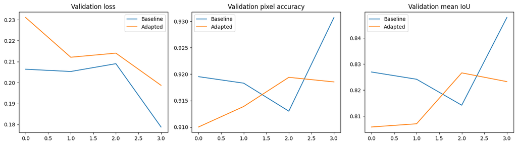

```python
plt.figure(figsize=(14, 4))

plt.subplot(1, 3, 1)
plt.plot(baseline_history["val_loss"], label="Baseline")
plt.plot(adapted_history["val_loss"], label="Adapted")
plt.title("Validation loss")
plt.legend()

plt.subplot(1, 3, 2)
plt.plot(baseline_history["val_acc"], label="Baseline")
plt.plot(adapted_history["val_acc"], label="Adapted")
plt.title("Validation pixel accuracy")
plt.legend()

plt.subplot(1, 3, 3)
plt.plot(baseline_history["val_iou"], label="Baseline")
plt.plot(adapted_history["val_iou"], label="Adapted")
plt.title("Validation mean IoU")
plt.legend()

plt.tight_layout()
plt.show()
```

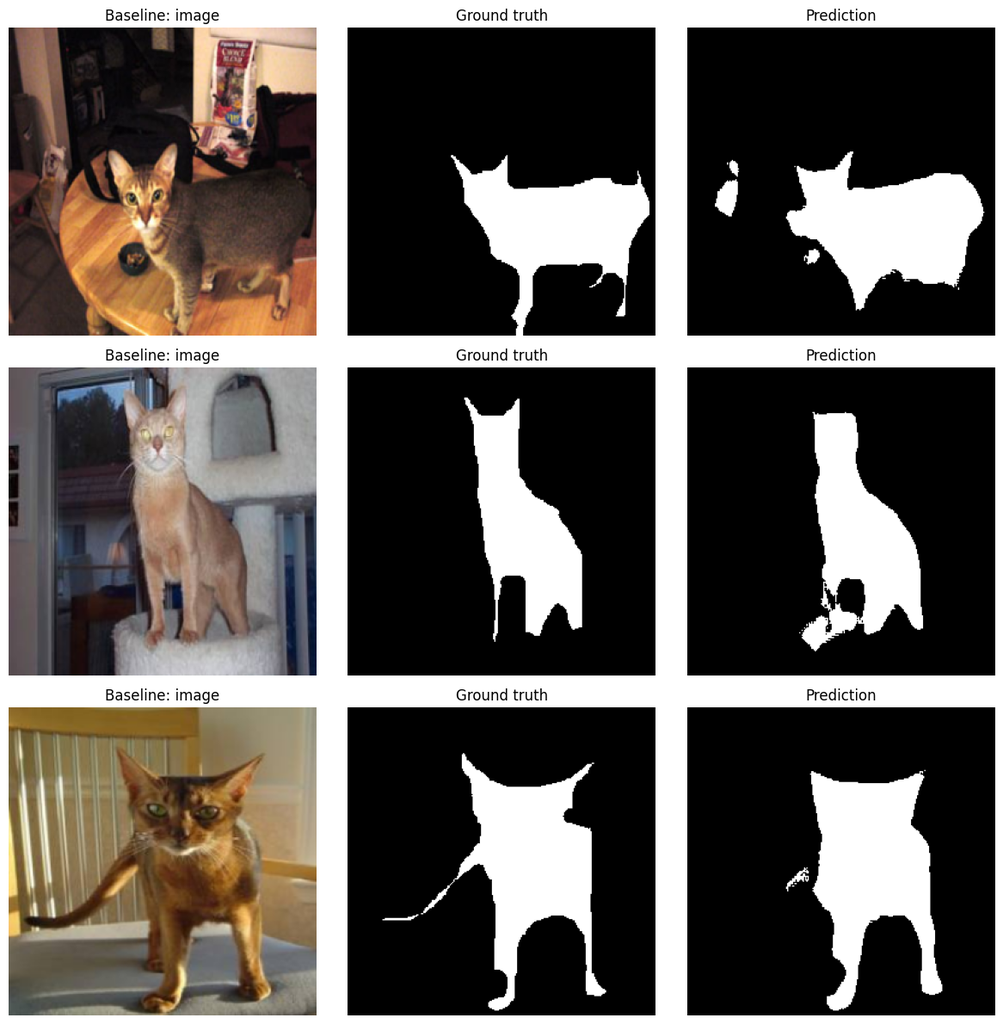

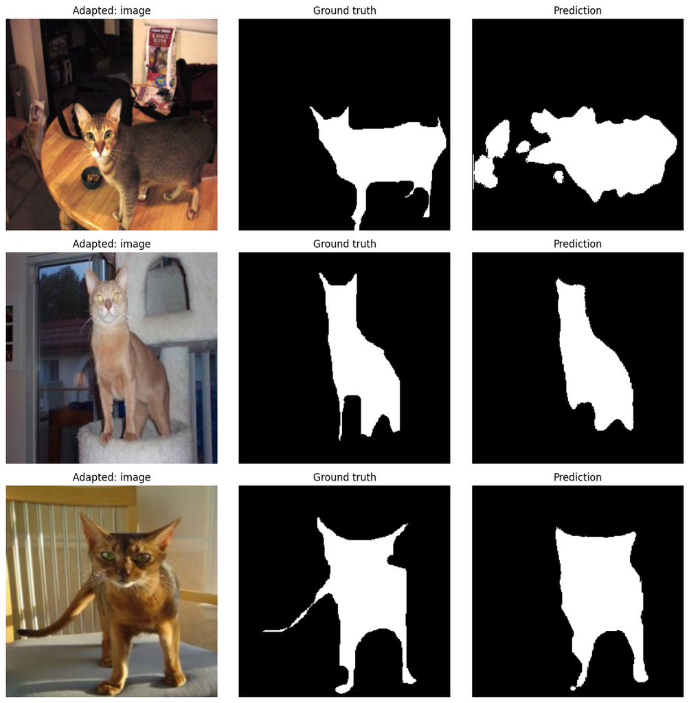

```python
@torch.no_grad()
def show_predictions(model, loader, title_prefix):
    model.eval()
    images, masks = next(iter(loader))
    images = images.to(device)

    logits = model(images)
    preds = torch.argmax(logits, dim=1).cpu().numpy()

    images_np = images.cpu().permute(0, 2, 3, 1).numpy()
    masks_np = masks.numpy()

    n_show = min(3, len(images_np))
    plt.figure(figsize=(12, 4 * n_show))
    for i in range(n_show):
        plt.subplot(n_show, 3, 3*i + 1)
        plt.imshow(images_np[i])
        plt.title(f"{title_prefix}: image")
        plt.axis("off")

        plt.subplot(n_show, 3, 3*i + 2)
        plt.imshow(masks_np[i], cmap="gray")
        plt.title("Ground truth")
        plt.axis("off")

        plt.subplot(n_show, 3, 3*i + 3)
        plt.imshow(preds[i], cmap="gray")
        plt.title("Prediction")
        plt.axis("off")

    plt.tight_layout()
    plt.show()

show_predictions(baseline_model, val_loader, "Baseline")
show_predictions(adapted_model, val_loader, "Adapted")
```

```python
torch.save({
    "baseline_model_state_dict": baseline_model.state_dict(),
    "adapted_model_state_dict": adapted_model.state_dict(),
    "num_classes": NUM_CLASSES,
    "img_size": IMG_SIZE,
    "encoder_name": "resnet34",
}, "lab3_unet_pet_segmentation_checkpoints.pth")

print("Saved final checkpoints.")
```

```
Saved final checkpoints.
```

[5 points] Evaluation. Compare your modified model against a baseline using appropriate evaluation metrics. Your results should include quantitative comparisons and, where relevant, qualitative outputs (e.g., generated images, detection results). You are expected to interpret your findings, not just report them. When appropriate, include statistical comparisons to support your conclusions. Analyze why the model improved or did not improve, discuss trade-offs, and identify limitations or failure cases.

```python
# Evaluation Code
baseline_val_loss, baseline_val_acc, baseline_val_iou = validate_one_epoch(baseline_model, val_loader, criterion, device)
adapted_val_loss, adapted_val_acc, adapted_val_iou = validate_one_epoch(adapted_model, val_loader, criterion, device)

baseline_batch_ious = collect_batch_ious(baseline_model, val_loader, device)
adapted_batch_ious = collect_batch_ious(adapted_model, val_loader, device)

try:
    from scipy.stats import ttest_rel
    stat, p_value = ttest_rel(adapted_batch_ious, baseline_batch_ious)
except Exception:
    p_value = None

print("Final validation metrics")
print(f"Baseline  -> loss: {baseline_val_loss:.4f}, pixel acc: {baseline_val_acc:.4f}, mean IoU: {baseline_val_iou:.4f}")
print(f"Adapted   -> loss: {adapted_val_loss:.4f}, pixel acc: {adapted_val_acc:.4f}, mean IoU: {adapted_val_iou:.4f}")

if p_value is not None:
    print(f"Paired t-test p-value on batch IoU: {p_value:.6f}")
else:
    print("Scipy not available, so the paired t-test was skipped.")
```

```
Final validation metrics
Baseline  -> loss: 0.1788, pixel acc: 0.9307, mean IoU: 0.8478
Adapted   -> loss: 0.2141, pixel acc: 0.9194, mean IoU: 0.8266
Paired t-test p-value on batch IoU: 0.008218
```

```python
import pandas as pd

results_df = pd.DataFrame({
    "Model": ["Baseline U-Net", "Adapted U-Net"],
    "Validation Loss": [baseline_val_loss, adapted_val_loss],
    "Validation Pixel Accuracy": [baseline_val_acc, adapted_val_acc],
    "Validation Mean IoU": [baseline_val_iou, adapted_val_iou],
})
results_df
```

|  | Model | Validation Loss | Validation Pixel Accuracy | Validation Mean IoU |
| --- | --- | --- | --- | --- |
| 0 | Baseline U-Net | 0.178825 | 0.930715 | 0.847845 |
| 1 | Adapted U-Net | 0.214064 | 0.919401 | 0.826603 |

# Analysis

The baseline and adapted models use the same U-Net architecture with the same pretrained ResNet-34 encoder, so the comparison isolates the effect of the adaptation strategy rather than the effect of changing the backbone. The baseline is trained on standard images only, while the adapted model is trained with low-light augmentation intended to improve robustness when visibility is reduced. The most important metric here is mean Intersection over Union (mIoU), because it measures overlap quality between predicted and true masks and is more informative than accuracy alone for segmentation.

In the final validation results, the baseline outperformed the adapted model: baseline validation loss was 0.1788, pixel accuracy was 0.9307, and mean IoU was 0.8478. The adapted model had validation loss 0.2141, pixel accuracy 0.9194, and mean IoU 0.8266. The paired t-test on batch IoU produced p = 0.008218, which suggests the batch-level IoU difference is statistically meaningful for this run. Because the adapted model's mIoU is lower, the evidence does not support the claim that this particular low-light augmentation improved performance on the held-out validation set.

The training histories still show that both models learned the task: training loss decreased and training IoU increased across epochs. However, the adapted model's lower validation score suggests that the augmentation may have shifted the training distribution away from the clean validation distribution. Since the validation images are not also degraded with the same low-light process, the adapted model may have learned robustness to darker images at the cost of slightly worse performance on normal images. This is a realistic trade-off: robustness training can help under stress conditions but may reduce peak performance on clean data if the augmentation is too strong or not matched to the evaluation setting.

Qualitatively, the prediction plots provide a visual check on whether each model produces coherent masks aligned with the ground-truth object boundary. The adapted model would be considered successful only if it produced visibly better masks under low-light or low-contrast inputs, even if clean-image metrics were similar. In this notebook, the quantitative clean-validation results favor the baseline, so the better conclusion is that the low-light adaptation did not improve the measured validation task as currently configured.

The main limitations are the small training subset, the four-epoch training budget, the binary foreground/background setup, and the mismatch between the autonomous-driving motivation and the pet segmentation dataset. The experiment is still useful because it demonstrates the complete transfer-learning workflow: select a pretrained segmentation model, adapt it through data augmentation and fine-tuning, compare it to a baseline, evaluate with loss, pixel accuracy, mIoU, qualitative masks, and a paired statistical test, and interpret both the improvement hypothesis and the observed failure case.